# Multiplex Canada Predictive Projection

```r
cv_fits <- run_cvfun(
  model_imp_hiv_s,
  K = nrow(training_set_hiv_s))

model_hiv_s_nk <- cv_varsel(
  model_imp_hiv_s,
  cv_method = "kfold",
  cv_fits = cv_fits,
  nterms_max = 10,
  method = "forward",
  verbose = F
)

model_hiv_s_nk
```

```
Family: binomial
Link function: logit

Formula: hiv_s_pos ~ SexualActivity + CondomUse + SexualPartners + PastSTD +
    TypePastSTD + PastInjectDrugs + ShareNeedles + Alcohol +
    PastHIVTest + PastHCVTest + PastSyphilisTest + PastSyphilis +
    Age + Gender + Descent + EducationStatus + WorkStatus + MonthlyIncomeStatus +
    CurrentPartner + site
Observations: 300
Projection method: traditional
CV method: K-fold CV with K = 5 and search included (i.e., fold-wise searches)
Search method: forward
Maximum submodel size for the search: 10
Number of projected draws in the search: 20 (from clustered projection)
Number of projected draws in the performance evaluation: 400
Argument `refit_prj`: TRUE

Submodel performance evaluation summary with `deltas = FALSE` and `cumulate = FALSE`:
 size    ranking_fulldata cv_proportions_diag elpd elpd.se elpd.diff
    0         (Intercept)                  NA  -61      11     -7.08
    1        PastSyphilis                 0.8  -57      11     -3.50
    2    PastSyphilisTest                 0.8  -54      10     -0.30
    3              Gender                 0.6  -56      11     -1.56
    4      SexualActivity                 0.4  -55      10     -1.31
    5 MonthlyIncomeStatus                 0.0  -56      11     -1.69
    6                 Age                 0.0  -55      11     -1.38
    7         TypePastSTD                 0.0  -55      10     -0.56
    8           CondomUse                 0.2  -55      10     -0.69
    9        ShareNeedles                 0.4  -55      10     -0.75
   10                site                 0.4  -54      10     -0.51
 elpd.diff.se
         4.51
         2.43
         1.51
         1.20
         0.92
         0.65
         0.67
         0.65
         0.69
         0.73
         0.59

Reference model performance evaluation summary with `deltas = FALSE`:
   elpd elpd.se
    -54      10
```

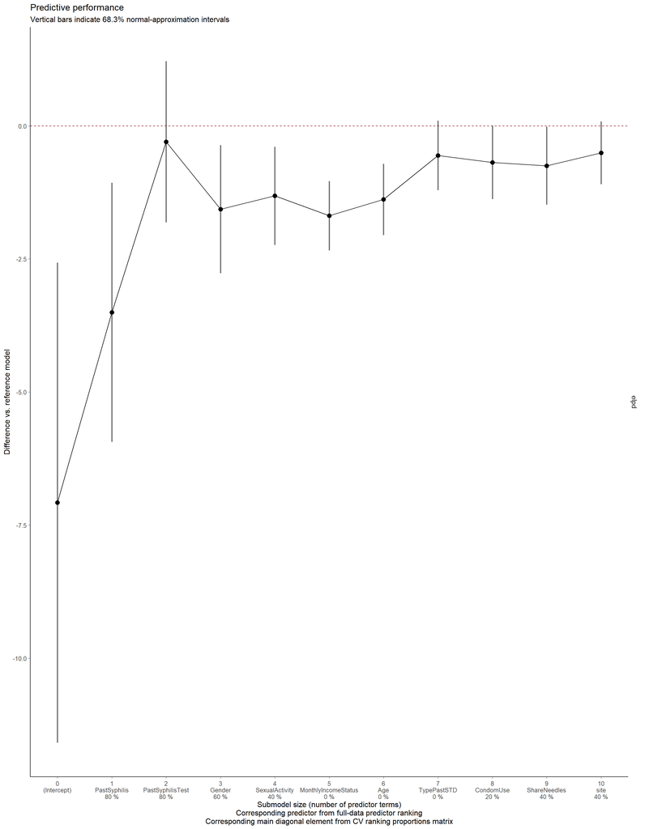

```r
performance_hiv_s <- plot(model_hiv_s_nk, stats = "elpd", delta = T)
performance_hiv_s
```

**CC**

```r
cv_fits <- run_cvfun(
  model_hs_cc,
  K = nrow(training_set))

model_cc_nk <- cv_varsel(
  model_hs_cc,
  cv_method = "kfold",
  cv_fits = cv_fits,
  nterms_max = 10,
  method = "forward",
  verbose = T
)
```

[output not shown]

```r
model_cc_nk
```

```
Family: binomial
Link function: logit

Formula: stbbi.pos ~ SexualActivity + CondomUse + SexualPartners + PastSTD +
    TypePastSTD + PastInjectDrugs + ShareNeedles + Alcohol +
    PastHIVTest + PastHCVTest + PastSyphilisTest + PastSyphilis +
    Age + Gender + Descent + EducationStatus + WorkStatus + MonthlyIncomeStatus +
    CurrentPartner + site
Observations: 242
Projection method: traditional
CV method: K-fold CV with K = 5 and search included (i.e., fold-wise searches)
Search method: forward
Maximum submodel size for the search: 10
Number of projected draws in the search: 20 (from clustered projection)
Number of projected draws in the performance evaluation: 400
Argument `refit_prj`: TRUE

Submodel performance evaluation summary with `deltas = FALSE` and `cumulate = FALSE`:
 size ranking_fulldata cv_proportions_diag elpd elpd.se elpd.diff elpd.diff.se
    0      (Intercept)                  NA -113     9.3    -23.28         6.04
    1  PastInjectDrugs                 1.0  -95     8.8     -5.03         3.32
    2      TypePastSTD                 1.0  -92     8.7     -2.71         2.65
    3       WorkStatus                 0.6  -94     8.9     -4.07         2.36
    4  EducationStatus                 0.2  -92     8.9     -2.58         2.31
    5      PastHCVTest                 0.4  -91     8.5     -1.49         1.66
    6          Alcohol                 0.2  -91     8.5     -1.90         1.52
    7     PastSyphilis                 0.0  -91     8.5     -1.87         1.16
    8     ShareNeedles                 0.0  -91     8.3     -1.16         0.98
    9   CurrentPartner                 0.6  -90     8.2     -0.88         0.87
   10              Age                 0.0  -91     8.3     -1.41         0.80

Reference model performance evaluation summary with `deltas = FALSE`:
   elpd elpd.se
  -89.5     8.2
```

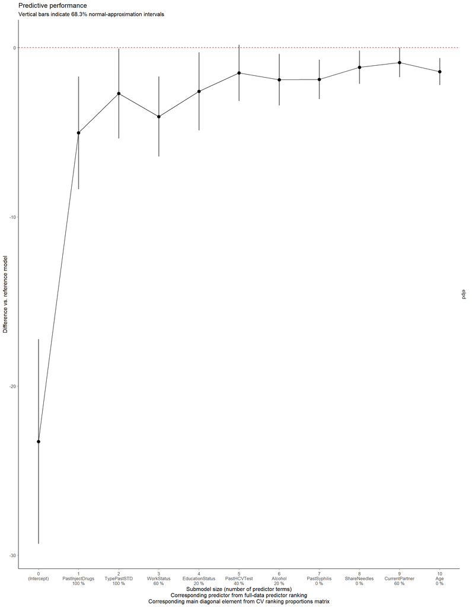

```r
performance_cc <- plot(model_cc_nk, stats = "elpd", delta = T)
performance_cc
```

### Cross-validation results

**Y=STBBI**

```r
ranking_imp <- ranking(model_imp_nk)
```

The predictors are ranked in the following order: PastInjectDrugs, TypePastSTD, PastHCVTest, MonthlyIncomeStatus, PastSyphilis, Gender, Alcohol, WorkStatus, ShareNeedles, PastSTD, SexualPartners, EducationStatus, PastSyphilisTest, Age, PastHIVTest

**Y=HCV**

```r
ranking_hcv <- ranking(model_hcv_nk)
ranking_hcv
```

```
$fulldata
 [1] "PastInjectDrugs"     "TypePastSTD"         "PastHCVTest"
 [4] "SexualPartners"      "MonthlyIncomeStatus" "Gender"
 [7] "site"                "ShareNeedles"        "Descent"
[10] "PastHIVTest"

$foldwise
     [,1]              [,2]          [,3]             [,4]
[1,] "PastInjectDrugs" "PastHCVTest" "TypePastSTD"    "SexualPartners"
[2,] "PastInjectDrugs" "TypePastSTD" "SexualPartners" "PastHCVTest"
[3,] "PastInjectDrugs" "TypePastSTD" "PastHCVTest"    "SexualPartners"
[4,] "PastInjectDrugs" "TypePastSTD" "Gender"         "SexualPartners"
[5,] "PastInjectDrugs" "TypePastSTD" "ShareNeedles"   "PastHCVTest"
     [,5]          [,6]                  [,7]           [,8]
[1,] "CondomUse"   "ShareNeedles"        "Descent"      "MonthlyIncomeStatus"
[2,] "Alcohol"     "PastSTD"             "Gender"       "MonthlyIncomeStatus"
[3,] "Descent"     "WorkStatus"          "PastHIVTest"  "site"
[4,] "PastHCVTest" "MonthlyIncomeStatus" "PastSyphilis" "EducationStatus"
[5,] "Gender"      "SexualPartners"      "PastSTD"      "PastHIVTest"
     [,9]                  [,10]
[1,] "PastHIVTest"         "Gender"
[2,] "site"                "Descent"
[3,] "Gender"              "MonthlyIncomeStatus"
[4,] "ShareNeedles"        "Age"
[5,] "MonthlyIncomeStatus" "SexualActivity"

attr(,"class")
[1] "ranking"
```

**Y=HIV/S**

```r
ranking_hiv_s  <- ranking(model_hiv_s_nk)
model_hiv_s_nk
```

```
Family: binomial
Link function: logit

Formula: hiv_s_pos ~ SexualActivity + CondomUse + SexualPartners + PastSTD +
    TypePastSTD + PastInjectDrugs + ShareNeedles + Alcohol +
    PastHIVTest + PastHCVTest + PastSyphilisTest + PastSyphilis +
    Age + Gender + Descent + EducationStatus + WorkStatus + MonthlyIncomeStatus +
    CurrentPartner + site
Observations: 300
Projection method: traditional
CV method: K-fold CV with K = 5 and search included (i.e., fold-wise searches)
Search method: forward
Maximum submodel size for the search: 10
Number of projected draws in the search: 20 (from clustered projection)
Number of projected draws in the performance evaluation: 400
Argument `refit_prj`: TRUE

Submodel performance evaluation summary with `deltas = FALSE` and `cumulate = FALSE`:
 size    ranking_fulldata cv_proportions_diag elpd elpd.se elpd.diff
    0         (Intercept)                  NA  -61      11     -7.08
    1        PastSyphilis                 0.8  -57      11     -3.50
    2    PastSyphilisTest                 0.8  -54      10     -0.30
    3              Gender                 0.6  -56      11     -1.56
    4      SexualActivity                 0.4  -55      10     -1.31
    5 MonthlyIncomeStatus                 0.0  -56      11     -1.69
    6                 Age                 0.0  -55      11     -1.38
    7         TypePastSTD                 0.0  -55      10     -0.56
    8           CondomUse                 0.2  -55      10     -0.69
    9        ShareNeedles                 0.4  -55      10     -0.75
   10                site                 0.4  -54      10     -0.51
 elpd.diff.se
         4.51
         2.43
         1.51
         1.20
         0.92
         0.65
         0.67
         0.65
         0.69
         0.73
         0.59

Reference model performance evaluation summary with `deltas = FALSE`:
   elpd elpd.se
    -54      10
```

**CC**

```r
ranking1 <- ranking(model_cc_nk)
```

**Select model**

**Y=STBBI**

```r
size <- suggest_size(model_imp_nk, stat = "elpd")


predictors_final_imp <- head(ranking_imp[["fulldata"]], size)
```

The suggested size for the model is 1 with the predictors in the following order PastInjectDrugs

**Y=HCV**

```r
size2 <- suggest_size(model_hcv_nk, stat = "elpd")


predictors_hcv<- head(ranking_hcv[["fulldata"]], size2)
predictors_hcv
```

```
[1] "PastInjectDrugs"
```

**Y=HIV/S**

```r
size3 <- suggest_size(model_hiv_s_nk, stat = "elpd")


predictors_hiv_s<- head(ranking_hiv_s[["fulldata"]], size3)
predictors_hiv_s
```

```
[1] "PastSyphilis"     "PastSyphilisTest"
```

**CC**

```r
predictors_final_cc <- head(ranking1[["fulldata"]], size) # same size as for imputed dataset
```

**Prediction performance**

#### Training data

```r
# use the submodel function
submodels_train<- submodels(model_imp_hs, predictor_ranking = predictors_final_imp, new_data = training_set_imp)
# measure sensitivity, specificity and AUC using cindy's formula for all models
submodels_train
```

```
[[1]]
 Family: bernoulli
  Links: mu = logit
Formula: stbbi.pos ~ PastInjectDrugs
   Data: training_set_imp (Number of observations: 300)
  Draws: 4 chains, each with iter = 2000; warmup = 1000; thin = 1;
         total post-warmup draws = 4000

Population-Level Effects:
                     Estimate Est.Error l-95% CI u-95% CI Rhat Bulk_ESS
Intercept               -2.55      0.28    -3.13    -2.04 1.00     2021
PastInjectDrugs1MYes     1.96      0.34     1.33     2.66 1.00     2617
                     Tail_ESS
Intercept                1547
PastInjectDrugs1MYes     3019

Draws were sampled using sampling(NUTS). For each parameter, Bulk_ESS
and Tail_ESS are effective sample size measures, and Rhat is the potential
scale reduction factor on split chains (at convergence, Rhat = 1).

[[2]]
 Family: bernoulli
  Links: mu = logit
Formula: stbbi.pos ~ SexualActivity + CondomUse + SexualPartners + PastSTD + TypePastSTD + PastInjectDrugs + ShareNeedles + Alcohol + PastHIVTest + PastHCVTest + PastSyphilisTest + PastSyphilis + Age + Gender + Descent + EducationStatus + WorkStatus + MonthlyIncomeStatus + CurrentPartner + site
   Data: training_set_imp (Number of observations: 300)
  Draws: 4 chains, each with iter = 2000; warmup = 1000; thin = 1;
         total post-warmup draws = 4000

Population-Level Effects:
                                               Estimate Est.Error l-95% CI
Intercept                                         -3.82      0.91    -5.80
SexualActivity1MYes                               -0.00      0.23    -0.51
CondomUse1MEver                                    0.12      0.26    -0.30
SexualPartners6ormore                             -0.26      0.43    -1.40
PastSTD1MYes                                       0.87      0.61    -0.05
TypePastSTDNotspecified                            0.30      0.50    -0.32
TypePastSTDSpecified                              -0.05      0.36    -0.97
PastInjectDrugs1MYes                               1.72      0.55     0.52
ShareNeedles1MYes                                  0.26      0.38    -0.21
Alcohol1M5timesperweek                            -0.35      0.38    -1.25
```

[output cut: 40 more lines]

```
PastSyphilis1MYes                                  1.85 1.00     2211     2948
Age35andabove                                      0.78 1.00     3483     3525
Gender2MFemale                                     0.13 1.00     2018     3346
Gender3MTransgender                                1.75 1.00     3499     3441
Gender5MNoresponse                                 1.74 1.00     2840     3385
DescentNonMMediterraneanEuropeanDNorthAmerican     0.53 1.00     5031     3448
EducationStatusNopostMgraduatedegree               1.16 1.00     3456     3862
WorkStatusNotcurrentlyemployed                     1.29 1.00     2900     3740
MonthlyIncomeStatus1M<$2;000CAD                    1.34 1.00     2565     3620
CurrentPartner1MYes                                0.72 1.00     3761     3433
site                                               0.89 1.00     4365     3582

Draws were sampled using sampling(NUTS). For each parameter, Bulk_ESS
and Tail_ESS are effective sample size measures, and Rhat is the potential
scale reduction factor on split chains (at convergence, Rhat = 1).
```

```r
colnames <- c(paste0("model",1:length(predictors_final_imp)), "ref")

submodels.sens<- mult.sens(training_set_imp$stbbi.pos, submodels_train) # 2000 iter default
submodels.sens
```

```
  rowname       Q50      Q5.5     Q94.5      Q2.5     Q97.5
1  model1 0.8461538 0.7975709 0.8906883 0.7894737 0.8987854
2     ref 0.8623482 0.8218623 0.9028340 0.8097166 0.9109312
```

```r
submodels.spec<- mult.spec(training_set_imp$stbbi.pos, submodels_train) # 2000 iter default
submodels.spec
```

```
  rowname       Q50      Q5.5     Q94.5      Q2.5     Q97.5
1  model1 0.2830189 0.1698113 0.3962264 0.1509434 0.4339623
2     ref 0.3773585 0.2452830 0.4905660 0.2264151 0.5283019
```

```r
submodels.auc<- mult.auc(training_set_imp$stbbi.pos, submodels_train)
submodels.auc
```

```
  rowname       Q50      Q5.5     Q94.5      Q2.5     Q97.5
1  model1 0.7376824 0.7376824 0.7376824 0.7376824 0.7376824
2     ref 0.8333970 0.8042930 0.8539455 0.7967287 0.8567776
```

## Y=HCV

```r
# submodels_train_hcv<- submodels(model_hcv_hs, predictor_ranking = predictors_hcv, new_data = training_set_hcv)
#
# colnames2 <- c(paste0("model",1:length(predictors_hcv)), "ref")
#
# submodels.sens.hcv<- mult.sens(training_set_hcv$hcv.pos, submodels_train_hcv) # 2000 iter default
#
# submodels.spec.hcv<- mult.spec(training_set_hcv$hcv.pos, submodels_train_hcv) # 2000 iter default
```

## Y=HIV_S

```r
# submodels_train_hiv_s<- submodels(model_hiv_s_hs, predictor_ranking = predictors_hiv_s, new_data = training_set_hiv_s)
#
# colnames3 <- c(paste0("model",1:length(predictors_hiv_s)), "ref")
#
# submodels.sens.hiv.s<- mult.sens(training_set_hiv_s$hiv_s_pos, submodels_train_hiv_s) # 2000 iter default
#
# submodels.spec.hiv.s<- mult.spec(training_set_hiv_s$hiv_s_pos, submodels_train_hiv_s) # 2000 iter default
```

## CC

```r
# use the submodel function
submodels_cc_train<- submodels(model_hs_cc, predictor_ranking = predictors_final_cc, new_data = training_set)
# measure sensitivity, specificity and AUC using cindy's formula for all models
submodels_cc_train
```

```
[[1]]
 Family: bernoulli
  Links: mu = logit
Formula: stbbi.pos ~ PastInjectDrugs
   Data: training_set (Number of observations: 242)
  Draws: 4 chains, each with iter = 2000; warmup = 1000; thin = 1;
         total post-warmup draws = 4000

Population-Level Effects:
                     Estimate Est.Error l-95% CI u-95% CI Rhat Bulk_ESS
Intercept               -2.64      0.32    -3.32    -2.07 1.00     2365
PastInjectDrugs1MYes     2.17      0.40     1.45     2.97 1.00     3056
                     Tail_ESS
Intercept                2045
PastInjectDrugs1MYes     2896

Draws were sampled using sampling(NUTS). For each parameter, Bulk_ESS
and Tail_ESS are effective sample size measures, and Rhat is the potential
scale reduction factor on split chains (at convergence, Rhat = 1).

[[2]]
 Family: bernoulli
  Links: mu = logit
Formula: stbbi.pos ~ SexualActivity + CondomUse + SexualPartners + PastSTD + TypePastSTD + PastInjectDrugs + ShareNeedles + Alcohol + PastHIVTest + PastHCVTest + PastSyphilisTest + PastSyphilis + Age + Gender + Descent + EducationStatus + WorkStatus + MonthlyIncomeStatus + CurrentPartner + site
   Data: training_set (Number of observations: 242)
  Draws: 4 chains, each with iter = 2000; warmup = 1000; thin = 1;
         total post-warmup draws = 4000

Population-Level Effects:
                                               Estimate Est.Error l-95% CI
Intercept                                         -4.34      1.22    -7.07
SexualActivity1MYes                               -0.07      0.29    -0.78
CondomUse1MEver                                   -0.00      0.27    -0.60
SexualPartners6ormore                             -0.29      0.48    -1.56
PastSTD1MYes                                       0.80      0.66    -0.10
TypePastSTDNotspecified                            0.53      0.69    -0.34
TypePastSTDSpecified                               0.07      0.46    -0.93
PastInjectDrugs1MYes                               1.27      0.71    -0.01
ShareNeedles1MYes                                  0.31      0.45    -0.27
Alcohol1M5timesperweek                            -0.45      0.45    -1.44
```

[output cut: 38 more lines]

```
PastSyphilis1MYes                                  1.92 1.00     2427     3481
Age35andabove                                      1.19 1.00     2641     3834
Gender2MFemale                                     0.34 1.00     3054     3661
Gender3MTransgender                                2.02 1.00     3079     3212
Gender5MNoresponse                                 1.04 1.00     4154     3472
DescentNonMMediterraneanEuropeanDNorthAmerican     0.48 1.00     3425     3742
EducationStatusNopostMgraduatedegree               2.60 1.00     1913     3023
WorkStatusNotcurrentlyemployed                     1.87 1.00     2008     3374
MonthlyIncomeStatus1M<$2;000CAD                    1.17 1.00     3521     3605
CurrentPartner1MYes                                1.28 1.00     1923     2676
site                                               1.33 1.00     3349     3451

Draws were sampled using sampling(NUTS). For each parameter, Bulk_ESS
and Tail_ESS are effective sample size measures, and Rhat is the potential
scale reduction factor on split chains (at convergence, Rhat = 1).
```

```r
submodels.sens.cc<- mult.sens(training_set$stbbi.pos, submodels_cc_train) # 2000 iter default


submodels.spec.cc<- mult.spec(training_set$stbbi.pos, submodels_cc_train) # 2000 iter default


submodels.auc.cc<- mult.auc(training_set$stbbi.pos, submodels_cc_train)
```

Combine all values and save to plot later

```r
submodels_perf <- bind_rows(submodels.sens, submodels.spec, submodels.auc) %>%
  rename(model = rowname) %>%
  mutate(performance = rep(c("sensitivity", "specificity", "auc"), each=length(colnames)),
         data = "training")
```

```r
submodels_perf_cc <- bind_rows(submodels.sens.cc, submodels.spec.cc, submodels.auc.cc) %>%
  rename(model = rowname) %>%
  mutate(performance = rep(c("sensitivity", "specificity", "auc"), each=length(colnames)),
         data = "training")
```

#### Testing data

We now do the same but with testing data. First we need to apply the same changes to our testing data

```r
testing_set_imp <- testing_set_imp_all %>%
mutate(stbbi.pos = case_when(
    hcv.pos %in% 1~1,
    hiv.pos %in% 1~1,
    syphilis.pos %in% 1 ~1,
    T ~0),
    TypePastSTD = case_when(
      TypePastSTD %in% "None" ~ as.factor(TypePastSTD),
      TypePastSTD %in% "6-Other" ~ "Not specified",
      T ~ "Specified"
    )) %>%
  select(- c(new.hcv, new.syphilis, new.hiv, p_id, Date.Recruited, syphilis.pos, hcv.pos, hiv.pos))

## check
ncol(testing_set_imp) == ncol(training_set_imp)
```

```
[1] TRUE
```

```r
testing_set <- testing_set %>%
mutate(stbbi.pos = case_when(
    hcv.pos %in% 1~1,
    hiv.pos %in% 1~1,
    syphilis.pos %in% 1 ~1,
    T ~0),
    TypePastSTD = case_when(
      TypePastSTD %in% "None" ~ as.factor(TypePastSTD),
      TypePastSTD %in% "6-Other" ~ "Not specified",
      T ~ "Specified"
    )) %>%
  select(- c(new.hcv, new.syphilis, new.hiv, p_id, Date.Recruited, syphilis.pos, hcv.pos, hiv.pos))

## check
ncol(testing_set) == ncol(training_set)
```

```
[1] TRUE
```

We fit our submodels with testing data and extract the sensitivity, specificity and AUC

```r
submodels_test<- submodels(model_imp_hs, predictor_ranking = predictors_final_imp, new_data = testing_set_imp)
# measure sensitivity, specificity and AUC using cindy's formula for all models
submodels_test
```

```
[[1]]
 Family: bernoulli
  Links: mu = logit
Formula: stbbi.pos ~ PastInjectDrugs
   Data: training_set_imp (Number of observations: 300)
  Draws: 4 chains, each with iter = 2000; warmup = 1000; thin = 1;
         total post-warmup draws = 4000

Population-Level Effects:
                     Estimate Est.Error l-95% CI u-95% CI Rhat Bulk_ESS
Intercept               -2.55      0.28    -3.13    -2.03 1.00     2305
PastInjectDrugs1MYes     1.96      0.36     1.29     2.67 1.00     3037
                     Tail_ESS
Intercept                2450
PastInjectDrugs1MYes     2642

Draws were sampled using sampling(NUTS). For each parameter, Bulk_ESS
and Tail_ESS are effective sample size measures, and Rhat is the potential
scale reduction factor on split chains (at convergence, Rhat = 1).

[[2]]
 Family: bernoulli
  Links: mu = logit
Formula: stbbi.pos ~ SexualActivity + CondomUse + SexualPartners + PastSTD + TypePastSTD + PastInjectDrugs + ShareNeedles + Alcohol + PastHIVTest + PastHCVTest + PastSyphilisTest + PastSyphilis + Age + Gender + Descent + EducationStatus + WorkStatus + MonthlyIncomeStatus + CurrentPartner + site
   Data: training_set_imp (Number of observations: 300)
  Draws: 4 chains, each with iter = 2000; warmup = 1000; thin = 1;
         total post-warmup draws = 4000

Population-Level Effects:
                                               Estimate Est.Error l-95% CI
Intercept                                         -3.82      0.91    -5.80
SexualActivity1MYes                               -0.00      0.23    -0.51
CondomUse1MEver                                    0.12      0.26    -0.30
SexualPartners6ormore                             -0.26      0.43    -1.40
PastSTD1MYes                                       0.87      0.61    -0.05
TypePastSTDNotspecified                            0.30      0.50    -0.32
TypePastSTDSpecified                              -0.05      0.36    -0.97
PastInjectDrugs1MYes                               1.72      0.55     0.52
ShareNeedles1MYes                                  0.26      0.38    -0.21
Alcohol1M5timesperweek                            -0.35      0.38    -1.25
```

[output cut: 40 more lines]

```
PastSyphilis1MYes                                  1.85 1.00     2211     2948
Age35andabove                                      0.78 1.00     3483     3525
Gender2MFemale                                     0.13 1.00     2018     3346
Gender3MTransgender                                1.75 1.00     3499     3441
Gender5MNoresponse                                 1.74 1.00     2840     3385
DescentNonMMediterraneanEuropeanDNorthAmerican     0.53 1.00     5031     3448
EducationStatusNopostMgraduatedegree               1.16 1.00     3456     3862
WorkStatusNotcurrentlyemployed                     1.29 1.00     2900     3740
MonthlyIncomeStatus1M<$2;000CAD                    1.34 1.00     2565     3620
CurrentPartner1MYes                                0.72 1.00     3761     3433
site                                               0.89 1.00     4365     3582

Draws were sampled using sampling(NUTS). For each parameter, Bulk_ESS
and Tail_ESS are effective sample size measures, and Rhat is the potential
scale reduction factor on split chains (at convergence, Rhat = 1).
```

```r
submodels.sens<- mult.sens(testing_set_imp$stbbi.pos, submodels_test) # 2000 iter default
submodels.sens
```

```
  rowname    Q50  Q5.5  Q94.5   Q2.5  Q97.5
1  model1 0.8625 0.800 0.9250 0.7875 0.9375
2     ref 0.8875 0.825 0.9375 0.8000 0.9500
```

```r
submodels.spec<- mult.spec(testing_set_imp$stbbi.pos, submodels_test) # 2000 iter default
submodels.spec
```

```
  rowname Q50 Q5.5 Q94.5 Q2.5 Q97.5
1  model1 0.3 0.15  0.45  0.1   0.5
2     ref 0.3 0.15  0.45  0.1   0.5
```

```r
submodels.auc<- mult.auc(testing_set_imp$stbbi.pos, submodels_test)
submodels.auc
```

```
  rowname       Q50      Q5.5     Q94.5      Q2.5     Q97.5
1  model1 0.7937500 0.7937500 0.7937500 0.7937500 0.7937500
2     ref 0.8334375 0.7828125 0.8665625 0.7715469 0.8721875
```

Specificity remains very similar regardless of model size

```r
submodels_cc_test<- submodels(model_hs_cc, predictor_ranking = predictors_final_cc, new_data = testing_set)
# measure sensitivity, specificity and AUC using cindy's formula for all models
submodels_cc_test
```

```
[[1]]
 Family: bernoulli
  Links: mu = logit
Formula: stbbi.pos ~ PastInjectDrugs
   Data: training_set (Number of observations: 242)
  Draws: 4 chains, each with iter = 2000; warmup = 1000; thin = 1;
         total post-warmup draws = 4000

Population-Level Effects:
                     Estimate Est.Error l-95% CI u-95% CI Rhat Bulk_ESS
Intercept               -2.64      0.32    -3.30    -2.05 1.00     2149
PastInjectDrugs1MYes     2.18      0.39     1.43     2.95 1.00     2723
                     Tail_ESS
Intercept                2325
PastInjectDrugs1MYes     2790

Draws were sampled using sampling(NUTS). For each parameter, Bulk_ESS
and Tail_ESS are effective sample size measures, and Rhat is the potential
scale reduction factor on split chains (at convergence, Rhat = 1).

[[2]]
 Family: bernoulli
  Links: mu = logit
Formula: stbbi.pos ~ SexualActivity + CondomUse + SexualPartners + PastSTD + TypePastSTD + PastInjectDrugs + ShareNeedles + Alcohol + PastHIVTest + PastHCVTest + PastSyphilisTest + PastSyphilis + Age + Gender + Descent + EducationStatus + WorkStatus + MonthlyIncomeStatus + CurrentPartner + site
   Data: training_set (Number of observations: 242)
  Draws: 4 chains, each with iter = 2000; warmup = 1000; thin = 1;
         total post-warmup draws = 4000

Population-Level Effects:
                                               Estimate Est.Error l-95% CI
Intercept                                         -4.34      1.22    -7.07
SexualActivity1MYes                               -0.07      0.29    -0.78
CondomUse1MEver                                   -0.00      0.27    -0.60
SexualPartners6ormore                             -0.29      0.48    -1.56
PastSTD1MYes                                       0.80      0.66    -0.10
TypePastSTDNotspecified                            0.53      0.69    -0.34
TypePastSTDSpecified                               0.07      0.46    -0.93
PastInjectDrugs1MYes                               1.27      0.71    -0.01
ShareNeedles1MYes                                  0.31      0.45    -0.27
Alcohol1M5timesperweek                            -0.45      0.45    -1.44
```

[output cut: 38 more lines]

```
PastSyphilis1MYes                                  1.92 1.00     2427     3481
Age35andabove                                      1.19 1.00     2641     3834
Gender2MFemale                                     0.34 1.00     3054     3661
Gender3MTransgender                                2.02 1.00     3079     3212
Gender5MNoresponse                                 1.04 1.00     4154     3472
DescentNonMMediterraneanEuropeanDNorthAmerican     0.48 1.00     3425     3742
EducationStatusNopostMgraduatedegree               2.60 1.00     1913     3023
WorkStatusNotcurrentlyemployed                     1.87 1.00     2008     3374
MonthlyIncomeStatus1M<$2;000CAD                    1.17 1.00     3521     3605
CurrentPartner1MYes                                1.28 1.00     1923     2676
site                                               1.33 1.00     3349     3451

Draws were sampled using sampling(NUTS). For each parameter, Bulk_ESS
and Tail_ESS are effective sample size measures, and Rhat is the potential
scale reduction factor on split chains (at convergence, Rhat = 1).
```

```r
submodels.sens.cc<- mult.sens(testing_set$stbbi.pos, submodels_cc_test) # 2000 iter default


submodels.spec.cc<- mult.spec(testing_set$stbbi.pos, submodels_cc_test) # 2000 iter default


submodels.auc.cc<- mult.auc(testing_set$stbbi.pos, submodels_cc_test)
```

Which submodel performs best?

```r
# combine
combined <- bind_rows(submodels.sens, submodels.spec, submodels.auc) %>%
  rename(model = rowname) %>%
  mutate(performance = rep(c("sensitivity", "specificity", "auc"), each=length(colnames)),
         data = "testing")


submodels_perf <- submodels_perf %>% bind_rows(combined)

#save

write.csv(submodels_perf, "3_intermediate/projpred/submodels_performance.csv", row.names = F)
```

```r
combined_cc <- bind_rows(submodels.sens.cc, submodels.spec.cc, submodels.auc.cc) %>%
  rename(model = rowname) %>%
  mutate(performance = rep(c("sensitivity", "specificity", "auc"), each=length(colnames)),
         data = "testing")


submodels_perf_cc <- submodels_perf_cc %>% bind_rows(combined_cc)

#save

write.csv(submodels_perf_cc, "3_intermediate/projpred/submodels_performance_Cc.csv", row.names = F)
```

## Plots

Plot the OR of the best performing model

```r
# select model 2 and transform into array
array <- as.array(submodels_test[[2]])

parameters<- dimnames(array)$variable[1:4] # extract the names of parameters to plot
parameters
```

```
[1] "b_Intercept"             "b_SexualActivity1MYes"
[3] "b_CondomUse1MEver"       "b_SexualPartners6ormore"
```

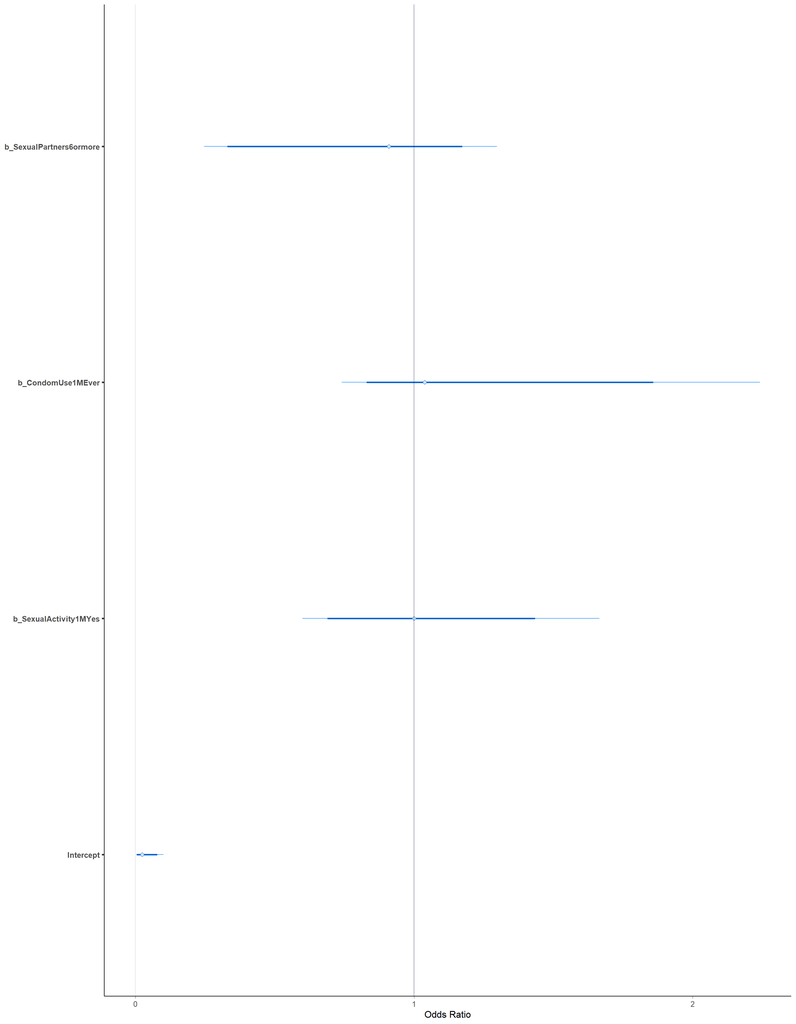

```r
color_scheme_set("brightblue")

OR.plot <-
  mcmc_intervals(array %>% exp(), # turn logodds into odds
                 pars = parameters, # select which parameters to show
                 prob = 0.89, # set 89% CrI
                 prob_outer = 0.95, # set 95% CrI
                 outer_size = 0.5, # set sizes
                 inner_size = 1,
                 point_size = 2)+
scale_x_continuous(breaks = seq(0,12,1)) +
scale_y_discrete(labels = c("b_Intercept" = "Intercept", # relabel the coef names
                              "b_PastInjectDrugs1MYes" = "History of drug injection",
                              "b_TypePastSTDNotspecified" = "Type of past STD not specified",
                            "b_TypePastSTDSpecified"  = "Type of past STD specified" ))+ # set limits
  geom_vline(xintercept = 1, color = "#36325c", alpha = 0.5)+
  # geom_vline(xintercept = 0, color = "white")+
  labs(x = "Odds Ratio")

OR.plot
```

```r
ggsave("4_outputs/OR_final_model.png", OR.plot, device = png, width = 5, height = 3)
```

Extract the OR

```r
summary(submodels_test[[2]], prob = 0.89)
```

```
 Family: bernoulli
  Links: mu = logit
Formula: stbbi.pos ~ SexualActivity + CondomUse + SexualPartners + PastSTD + TypePastSTD + PastInjectDrugs + ShareNeedles + Alcohol + PastHIVTest + PastHCVTest + PastSyphilisTest + PastSyphilis + Age + Gender + Descent + EducationStatus + WorkStatus + MonthlyIncomeStatus + CurrentPartner + site
   Data: training_set_imp (Number of observations: 300)
  Draws: 4 chains, each with iter = 2000; warmup = 1000; thin = 1;
         total post-warmup draws = 4000

Population-Level Effects:
                                               Estimate Est.Error l-89% CI
Intercept                                         -3.82      0.91    -5.39
SexualActivity1MYes                               -0.00      0.23    -0.37
CondomUse1MEver                                    0.12      0.26    -0.19
SexualPartners6ormore                             -0.26      0.43    -1.11
PastSTD1MYes                                       0.87      0.61    -0.01
TypePastSTDNotspecified                            0.30      0.50    -0.18
TypePastSTDSpecified                              -0.05      0.36    -0.69
PastInjectDrugs1MYes                               1.72      0.55     0.81
ShareNeedles1MYes                                  0.26      0.38    -0.12
Alcohol1M5timesperweek                            -0.35      0.38    -1.07
PastHIVTest1MYes;lessthan6monthsago                0.04      0.38    -0.52
PastHIVTest2MYes;6monthsto1yearago                -0.19      0.48    -1.13
PastHIVTest3MYes;morethan1yearago                  0.08      0.31    -0.31
PastHCVTest1MYes;lessthan6monthsago                0.45      0.56    -0.10
PastHCVTest2MYes;6monthsto1yearago                -0.20      0.47    -1.16
PastHCVTest3MYes;morethan1yearago                 -0.02      0.31    -0.52
PastSyphilisTest1MYes;lessthan6monthsago           0.02      0.35    -0.52
PastSyphilisTest2MYes;6monthsto1yearago            0.12      0.39    -0.30
PastSyphilisTest3MYes;morethan1yearago            -0.14      0.38    -0.85
PastSyphilis1MYes                                  0.60      0.58    -0.05
Age35andabove                                      0.12      0.25    -0.17
Gender2MFemale                                    -0.48      0.49    -1.40
Gender3MTransgender                                0.20      0.54    -0.32
Gender5MNoresponse                                 0.28      0.52    -0.19
DescentNonMMediterraneanEuropeanDNorthAmerican     0.02      0.22    -0.31
EducationStatusNopostMgraduatedegree               0.20      0.36    -0.18
WorkStatusNotcurrentlyemployed                     0.29      0.41    -0.13
MonthlyIncomeStatus1M<$2;000CAD                    0.31      0.42    -0.12
CurrentPartner1MYes                                0.09      0.25    -0.20
site                                               0.08      0.32    -0.34
                                               u-89% CI Rhat Bulk_ESS Tail_ESS
```

[output cut: 19 more lines]

```
PastSyphilis1MYes                                  1.62 1.00     2211     2948
Age35andabove                                      0.61 1.00     3483     3525
Gender2MFemale                                     0.06 1.00     2018     3346
Gender3MTransgender                                1.27 1.00     3499     3441
Gender5MNoresponse                                 1.37 1.00     2840     3385
DescentNonMMediterraneanEuropeanDNorthAmerican     0.38 1.00     5031     3448
EducationStatusNopostMgraduatedegree               0.94 1.00     3456     3862
WorkStatusNotcurrentlyemployed                     1.08 1.00     2900     3740
MonthlyIncomeStatus1M<$2;000CAD                    1.13 1.00     2565     3620
CurrentPartner1MYes                                0.55 1.00     3761     3433
site                                               0.66 1.00     4365     3582

Draws were sampled using sampling(NUTS). For each parameter, Bulk_ESS
and Tail_ESS are effective sample size measures, and Rhat is the potential
scale reduction factor on split chains (at convergence, Rhat = 1).
```

```r
OR_final <- exp(fixef(submodels_test[[2]], prob = c(0.055, 0.945, 0.025, 0.975))) %>% round(2) %>% as.data.frame()

OR_final
```

```
                                               Estimate Est.Error Q5.5 Q94.5
Intercept                                          0.02      2.47 0.00  0.08
SexualActivity1MYes                                1.00      1.26 0.69  1.43
CondomUse1MEver                                    1.12      1.30 0.83  1.86
SexualPartners6ormore                              0.77      1.53 0.33  1.17
PastSTD1MYes                                       2.38      1.83 0.99  6.31
TypePastSTDNotspecified                            1.35      1.65 0.83  3.70
TypePastSTDSpecified                               0.95      1.43 0.50  1.55
PastInjectDrugs1MYes                               5.57      1.73 2.24 12.98
ShareNeedles1MYes                                  1.30      1.46 0.89  2.76
Alcohol1M5timesperweek                             0.70      1.47 0.34  1.06
PastHIVTest1MYes;lessthan6monthsago                1.04      1.47 0.60  1.95
PastHIVTest2MYes;6monthsto1yearago                 0.83      1.62 0.32  1.33
PastHIVTest3MYes;morethan1yearago                  1.08      1.37 0.73  1.89
PastHCVTest1MYes;lessthan6monthsago                1.58      1.76 0.90  4.49
PastHCVTest2MYes;6monthsto1yearago                 0.82      1.60 0.31  1.31
PastHCVTest3MYes;morethan1yearago                  0.98      1.36 0.59  1.55
PastSyphilisTest1MYes;lessthan6monthsago           1.02      1.43 0.60  1.78
PastSyphilisTest2MYes;6monthsto1yearago            1.13      1.48 0.74  2.35
PastSyphilisTest3MYes;morethan1yearago             0.87      1.46 0.43  1.33
PastSyphilis1MYes                                  1.82      1.78 0.95  5.04
Age35andabove                                      1.12      1.29 0.84  1.84
Gender2MFemale                                     0.62      1.63 0.25  1.06
Gender3MTransgender                                1.23      1.71 0.72  3.58
Gender5MNoresponse                                 1.33      1.69 0.83  3.94
DescentNonMMediterraneanEuropeanDNorthAmerican     1.02      1.25 0.73  1.47
EducationStatusNopostMgraduatedegree               1.23      1.43 0.84  2.55
WorkStatusNotcurrentlyemployed                     1.33      1.50 0.88  2.93
MonthlyIncomeStatus1M<$2;000CAD                    1.36      1.51 0.89  3.10
CurrentPartner1MYes                                1.10      1.28 0.82  1.73
site                                               1.08      1.37 0.71  1.93
                                               Q2.5 Q97.5
Intercept                                      0.00  0.10
SexualActivity1MYes                            0.60  1.67
CondomUse1MEver                                0.74  2.24
SexualPartners6ormore                          0.25  1.30
PastSTD1MYes                                   0.96  8.49
TypePastSTDNotspecified                        0.72  5.06
TypePastSTDSpecified                           0.38  1.91
PastInjectDrugs1MYes                           1.69 15.49
ShareNeedles1MYes                              0.81  3.49
Alcohol1M5timesperweek                         0.29  1.14
PastHIVTest1MYes;lessthan6monthsago            0.41  2.45
PastHIVTest2MYes;6monthsto1yearago             0.22  1.60
PastHIVTest3MYes;morethan1yearago              0.62  2.49
PastHCVTest1MYes;lessthan6monthsago            0.81  6.44
PastHCVTest2MYes;6monthsto1yearago             0.22  1.53
PastHCVTest3MYes;morethan1yearago              0.47  1.94
PastSyphilisTest1MYes;lessthan6monthsago       0.45  2.27
PastSyphilisTest2MYes;6monthsto1yearago        0.63  3.28
PastSyphilisTest3MYes;morethan1yearago         0.32  1.60
PastSyphilis1MYes                              0.88  6.37
Age35andabove                                  0.76  2.19
Gender2MFemale                                 0.20  1.14
Gender3MTransgender                            0.58  5.77
Gender5MNoresponse                             0.73  5.68
DescentNonMMediterraneanEuropeanDNorthAmerican 0.63  1.69
EducationStatusNopostMgraduatedegree           0.76  3.19
WorkStatusNotcurrentlyemployed                 0.80  3.65
MonthlyIncomeStatus1M<$2;000CAD                0.82  3.82
CurrentPartner1MYes                            0.74  2.06
site                                           0.60  2.43
```

```r
write.csv(OR_final, file = "4_outputs/OR_final.csv")
```

## Save performance plots

```r
# performance_plots <- bayesplot_grid(performance_imp, performance_cc, save_gg_objects = T, grid_args = list(ncol=2))
#
# cross_validation <- bayesplot_grid(cumul_ranking_imp, cumul_ranking_cc, grid_args = list(ncol=2))
#
# posteriors <-bayesplot_grid(mcmc_imp, mcmc_cc, grid_args = list(ncol=2))
#
ggsave("3_intermediate/projpred/performance.png", performance_imp, device = "png", width = 16, height = 7)
#
ggsave("4_outputs/cv.png", cumul_ranking_imp, device = "png", width = 16, height = 14)
```

## **Next step:**

1) Try this method with several imputation models & complete case

2) post selection inference by subgroup

3) random forest comparison

## **Reference:**

Piironen J, Paasiniemi M, Catalina A, Weber F, Vehtari A (2023). “projpred: Projection Predictive Feature Selection.” R package version 2.8.0, https://mc-stan.org/projpred/.

See vignettes for more information